# Colon_Classifier (1)

### Classifiying gastrointestinal diseases using a variety of models from simple sequential CNNs, to transferred-learning models using Xception, EfficentNet, and InceptionV3.

In this project, we hope to accurately classify a variety of colon-related diseases using medical images. We will be limited on computing power so the size of the models we can build from scratch will be quite small, later in the project, we get around this by utilising transferred learning and incorporating the architecture, and weights of much larger and much more sophisticated models.

We will create a simple shallow CNN as a baseline and iterate on this to maximize performance.

#### Data Description

The data we will be looking at contains images of colons with one of three possible conditions, and also healthy colons. The three condition cateogires, and healthy category are:

- normal (healthy)
- ulcerative colitis
- polyps
- esophagitis

The images were collected in 2017 by Wireless Capsule Endoscopy (WCE) to help with the early diagnosis of colon cancer. These images were later used to better understand the three gastrointestinal diseases mentioned above, and create methods for automatically detecting their presnece.

#### Loading in the data

Since we already have the data split into train, test, and validation sets we will simply create a separate object for each to start with.

Despite the images being roughly 531x633 pixels large we choose to re-size them to 128x128, the logic behind this is simple; firstly, our GPU runtime is limited, reducing the dimensionality of the images will reduce the total number of parameters, making computation significantly faster. Secondly, the images are of high-quality medical images of the colon; naturally, colons are rather diverse, as such using the full-sized version of the images could very easily lead to over-fitting due to the natural noise of the images, for example, natural differences in coloration, bumps, and grooves.

The hope is that by re-sizing the images we will still capture the major featural differences that differentiate between the 4 categories, but with less noise.

```python
%pip install keras_tuner
```

```
     ━━━━━━━━━━━━━━━━━━━━━━━━━━━━━━━━━━━━━━━ 169.6/169.6 KB 4.9 MB/s eta 0:00:00
     ━━━━━━━━━━━━━━━━━━━━━━━━━━━━━━━━━━━━━━━━ 1.6/1.6 MB 33.3 MB/s eta 0:00:00
```

```python
from tensorflow import keras
from tensorflow.keras import layers
from tensorflow.keras.preprocessing.image import ImageDataGenerator
import tensorflow as tf
import tensorflow_datasets as tfds
from sklearn.metrics import f1_score
import numpy as np
import keras
import keras.backend as K
import keras_tuner as kt
from keras.callbacks import EarlyStopping
from tensorflow.keras import regularizers

import matplotlib.pyplot as plt
from datetime import datetime
from sklearn.metrics import classification_report

tf.get_logger().setLevel('ERROR')
```

```python
# dimensions to scale all images to
image_height = 128
image_width = 128

# The batch size to be used in our tensorflow dataset. (each element will be oh size (batch,height,width,depth))
batch_size = 32
```

```python
# load train data
train_data = tf.keras.utils.image_dataset_from_directory("/content/drive/MyDrive/archive/train",
                                                         seed=123, # seed ensures validation_split always takes the same 20%
                                                         image_size=(image_height,image_width),
                                                         batch_size=batch_size,
                                                         validation_split=0.2,
                                                         subset="training",
                                                         shuffle=True)
```

```
Found 3200 files belonging to 4 classes.
Using 2560 files for training.
```

```python
class_names = train_data.class_names # store class names as a variable for use in visualisations.
```

#### Checking the images

Now we have loaded our train data and saved it as a Tensorflow dataset we will quickly check to ensure the relevant information has been correctly stored, to do this we plot the first 16 images in the dataset with their corresponding labels. If the images have been loaded correctly, we should see 16 images of colons with the correct labels attached.

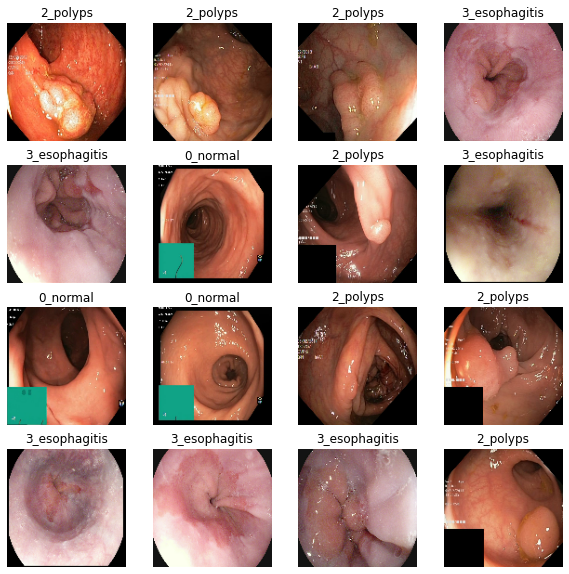

```python
# Code taken from deep learning with python, Edition 2
plt.figure(figsize=(10, 10))
for images, labels in train_data.take(1): # take the first batch from the train_data
  for i in range(16): # from the first batch, take the first 16 elements.
    ax = plt.subplot(4, 4, i + 1)
    plt.imshow(images[i].numpy().astype("uint8"))
    plt.title(class_names[labels[i]])
    plt.axis("off")
```

Now we have confirmed the training data has been succsefuly loaded we will repeat the process with the validation and test data.

```python
validation_data = tf.keras.utils.image_dataset_from_directory("/content/drive/MyDrive/archive/val",
                                                         seed=123,
                                                         image_size=(image_height,image_width),
                                                         batch_size=batch_size,
                                                         shuffle=True)



test_data = tf.keras.utils.image_dataset_from_directory("/content/drive/MyDrive/archive/test",
                                                         seed=123,
                                                         image_size=(image_height,image_width),
                                                         batch_size=batch_size,
                                                         shuffle=False)
```

```
Found 2000 files belonging to 4 classes.
Found 800 files belonging to 4 classes.
```

```python
# check the dimension of the tensors in the train set
def check_batch_dimensions(batch):
  '''This function takes a batch of images and their labels as input, and prints the shape and batch size of each image and label tensor.

  Args:
  batch: list of tuples, where each tuple contains a tensor representing a batch of images and a tensor representing a batch of labels.

  Returns:
  None

  '''

  for image_batch, label_batch in batch.take(1):
    print(f"tensor shape: {image_batch.shape} \
  \nbatch size: {label_batch.shape}")
```

```python
check_batch_dimensions(train_data)
```

```
tensor shape: (32, 128, 128, 3)
batch size: (32,)
```

```python
check_batch_dimensions(validation_data)
```

```
tensor shape: (32, 128, 128, 3)
batch size: (32,)
```

```python
check_batch_dimensions(test_data)
```

```
tensor shape: (32, 128, 128, 3)
batch size: (32,)
```

## preparing the data for modeling

#### cache and prefetch

Since our datasets are not huge we can cache them, meaning our datasets are saved in memory, as opposed to being read from disk each time the data is called. This greatly saves time, especially for deep-learning tasks where you may read/write the same dataset several hundred times when training a single model.

We also use auto-tuned pre-fetch which parallelises pre-processing and model executing between successive batches.

```python
def cache_and_prefetch(tf_dataset):
  '''
  This function caches and prefetches the data in a TensorFlow dataset to improve the performance of the data pipeline.

  Args:
  tf_dataset: a TensorFlow Dataset object to cache and prefetch.

  Returns:
  The same TensorFlow Dataset object with caching and prefetching applied.
  '''

  tf_dataset.cache().prefetch(buffer_size=tf.data.AUTOTUNE)
  return tf_dataset
```

```python
train_data = cache_and_prefetch(train_data)
validation_data = cache_and_prefetch(validation_data)
test_data = cache_and_prefetch(test_data)
```

#### Baseline model

Our three datasets have been successfully loaded. It is now time to start thinking about creating a model; Before we design, and optimise our final model we will spend a little time developing a simple baseline model to compare against.

The Baseline will be a shallow CNN with no regularization.

```python
normalization_layer = tf.keras.layers.Rescaling(1./255)

inputs = keras.Input(shape=(image_width,image_height,3))

x= normalization_layer(inputs)
x=layers.Conv2D(filters=64,kernel_size=3,activation="relu",padding="same")(x)
x=layers.MaxPooling2D(pool_size=2,padding="same")(x)
x=layers.Conv2D(filters=128,kernel_size=3,activation="relu",padding="same")(x)

x=layers.Flatten()(x)

outputs=layers.Dense(4,activation="softmax")(x)

base_line_model=keras.Model(inputs=inputs,outputs=outputs)
```

```python
base_line_model.summary()
```

```
Model: "model_1"
_________________________________________________________________
 Layer (type)                Output Shape              Param #
=================================================================
 input_2 (InputLayer)        [(None, 128, 128, 3)]     0

 rescaling_1 (Rescaling)     (None, 128, 128, 3)       0

 conv2d_2 (Conv2D)           (None, 128, 128, 64)      1792

 max_pooling2d_1 (MaxPooling  (None, 64, 64, 64)       0
 2D)

 conv2d_3 (Conv2D)           (None, 64, 64, 128)       73856

 flatten_1 (Flatten)         (None, 524288)            0

 dense_1 (Dense)             (None, 4)                 2097156

=================================================================
Total params: 2,172,804
Trainable params: 2,172,804
Non-trainable params: 0
_________________________________________________________________
```

Notice in the above summary that we are already up to almost 2.2million trainable parameters with this simple model. This could prove to be an issue later, we may need to consider lowering the resolution of our images further!

```python
base_line_model.compile(optimizer="adam",
              loss="sparse_categorical_crossentropy",
              metrics=["accuracy"])
```

#### Callbacks

Secondly, we define a callback to save weights during training, this isn't too useful for the baseline model since it only takes a minute or so to run, but our final model will presumably take a bit more time. saving weights during training allows us to get the best weights out if our program crashes or times out. We have it set to save off only the best weights based on validation accuracy, i.e if a given epoch has the highest validation accuracy the weights in that layer will be saved.

Thirdly, we define a custom callback that simply captures the time taken per epoch, this Epoch_Time is captured in the Callback.log() which can be accessed in the history object of the model. This means we can use it to create visualizations for training times.

```python
# custom callback for time per epoch
class EpochTime(keras.callbacks.Callback):
  def __init__(self,metric_name = "epoch_time"):
    self.__epoch_start = None
    self.__metric_name = metric_name
  def on_epoch_begin(self,epoch,logs=None):
    self.__epoch_start = tf.timestamp()
  def on_epoch_end(self,epoch,logs=None):
     logs[self.__metric_name] = tf.timestamp()-self.__epoch_start
```

```python
def earlystop(monitor="val_loss",min_delta=1e-4,patience=3):
  callback_earlystop = tf.keras.callbacks.EarlyStopping(
      monitor=monitor,
      min_delta=min_delta,
      patience=patience
  )
  return callback_earlystop

def checkpoints(filepath,monitor="val_accuracy"):
  callback_checkpoints = tf.keras.callbacks.ModelCheckpoint(
    filepath = filepath,
    monitor="val_accuracy",
    save_freq="epoch",
    save_weights_only=True,
    save_best_only=True
  )
  return callback_checkpoints
```

```python
callback_checkpoint_baseline = checkpoints("/content/drive/MyDrive/CW2_models/baseline_model/tmp/checkpoint")

callback_earlystop_baseline = earlystop()

history_baseline = base_line_model.fit(
  train_data,
  validation_data=validation_data,
  epochs=4,
  callbacks=[callback_checkpoint_baseline,callback_earlystop_baseline,EpochTime()]
)
```

```python
def eval_plots(history):
  """
    This function plots the training and validation loss and accuracy of a model.

    Parameters:
    history (keras.callbacks.History): the history object returned by the model fit function.

    Returns:
    None
  """
  history_dict = history.history

  loss = history_dict['loss']
  val_loss = history_dict['val_loss']

  accuracy=history_dict["accuracy"]
  val_accuracy = history_dict["val_accuracy"]

  epochs = range(1, len(loss) + 1)

  blue_dots = 'bo'
  solid_blue_line = 'b'

  red_dots = "ro"
  solid_red_line = "r"

  fig, (ax1,ax2) = plt.subplots(2,1,figsize=(10,5),sharex=True)

  ax1.plot(epochs, loss, blue_dots, label = 'Training loss')
  ax1.plot(epochs, val_loss, solid_blue_line, label = 'Validation loss')
  ax1.set_title('Training and validation loss')
  ax1.set_ylabel('Loss')
  ax1.legend()

  ax2.plot(epochs, accuracy, red_dots, label = 'Training Accuracy')
  ax2.plot(epochs, val_accuracy, solid_red_line, label = 'Validation Accuracy')
  ax2.set_title('Training and validation Accuracy')
  ax2.set_xlabel('Epochs')
  ax2.set_ylabel('Accuracy')
  ax2.legend()

  plt.show()

# This code has been adapted from the DLWP example code.
```

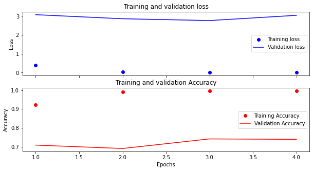

```python
eval_plots(history_baseline)
```

#### Data augmentation

A common method to reduce overfitting is to include a data augmentation layer, simply we apply a variety of random changes to our training images to create a more rich search space for our model to learn from, the changes must be realistic to ensure the extra information learned is transferable to un-seen, and un-augmented data.

Here we choose to include random vertical and horizontal flips, a change in image brightness, and cropping areas of 94x94 pixels. All of these changes should create a more rich search space, without creating any completely unrealistic images.

```python
augmentation_layer = keras.Sequential(
    [
     layers.RandomFlip("horizontal_and_vertical"),
     layers.RandomBrightness(0.3),
     layers.RandomCrop(height=94,
                       width=94,
                       seed=123)
    ]
)
```

Lets visualise the first 16 images of our train data to see what the augmentations look like, and visualise make sure we are not producing anything too different from the un-augmented images.

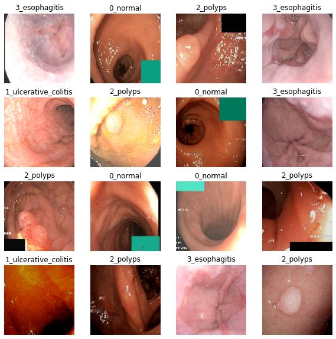

```python
# code slightly adapted from code in Deep Learning with python, second edition
plt.figure(figsize=(10, 10))
for images, labels in train_data.take(1): # take the first batch from the train_data
  augmented_images = augmentation_layer(images)  # apply augmentation layer to the first batch of images.
  for i in range(16): # from the first batch, take the first 16 elements.

    ax = plt.subplot(4, 4, i + 1)
    plt.imshow(augmented_images[i].numpy().astype("uint8"))
    plt.title(class_names[labels[i]])
    plt.axis("off")
```

We can see a variety of changes have taken effect on these first 16 images, but they all look realistic and different from the original images.

Next we will include this augmentation layer in our baseline model to see if itt adresses the overfitting problem.

```python
inputs = keras.Input(shape=(image_width,image_height,3))

x = augmentation_layer(inputs)
x= normalization_layer(x)
x=layers.Conv2D(filters=64,kernel_size=3,activation="relu",padding="same")(x)
x=layers.MaxPooling2D(pool_size=2,padding="same")(x)
x=layers.Conv2D(filters=128,kernel_size=3,activation="relu",padding="same")(x)

x=layers.Flatten()(x)

outputs=layers.Dense(4,activation="softmax")(x)

model_optimized_V1=keras.Model(inputs=inputs,outputs=outputs)

model_optimized_V1.compile(optimizer="Adam",
                loss="sparse_categorical_crossentropy",
                metrics=["accuracy"])

history_model_optimized_V1 = model_optimized_V1.fit(train_data, epochs=4,
                                                    validation_data=validation_data,
                                                    callbacks=[earlystop()
                                                               ,EpochTime()])
```

The model is still learning the training data quite quickly, we will also try reducing the number of filters, this should help with caputing higher-level features that are transferable rather than low-level intricate features that are not as transferable.

[figure not shown]

```python
eval_plots(history_model_optimized_V1)
```

introduce dropout layer and reduce number of filters.

```python
inputs = keras.Input(shape=(image_width,image_height,3))

x = augmentation_layer(inputs)
x= normalization_layer(x)

x=layers.Conv2D(filters=32,kernel_size=5,activation="relu",padding="same",
                kernel_regularizer=regularizers.L1L2(l1=1e-5, l2=1e-4))(x)

x=layers.Dropout(0.5)(x)

x=layers.Flatten()(x)

outputs=layers.Dense(4,activation="softmax")(x)

model_optimized_V2=keras.Model(inputs=inputs,outputs=outputs)

model_optimized_V2.compile(optimizer="Adam",
                loss="sparse_categorical_crossentropy",
                metrics=["accuracy"])
```

```python
model_optimized_V2_checkpoints = checkpoints("/content/drive/MyDrive/CW2_models/optimised_V2/tmp/checkpoints")
history_optimised_V2 = model_optimized_V2.fit(
  train_data,
  validation_data=validation_data,
  epochs=5,
  callbacks=[model_optimized_V2_checkpoints,earlystop(patience=5)]
)
```

We could spend time optimizing these simple CNN models by using a keras tuner, introducing hyperbands for all the hyperparameters, and changing the number and type of layers, but in reality, the performance increase will probably be quite small. We will save optimization for later models which are more promising. The natural next start would be to create an ensemble model or utilize more advanced search algorithms. We skip this step here since these models will suffer the same problems as the previous. I will provide an example of an inception model using hyperband optimization though as a learning exercise but I will not spend time running the optimization (I will compile it to show that it works, I just won't start the search).

## example optimization code for a homemade inception model.

Again we won't run this but hopefully, it gets across the idea of what's possible with the Keras tuner! (we will be using it later for our transferred-learning models but not to this extent)

#### What we included

We have an inception model that is made up of three branches, but each of those three branches is made up of customizable components. The optimization algorithm will iterate through sets of parameters (defined using the hp methods in the below code) which will choose what values to set the different hyperparameters at, whether or not to include more or fewer layers, and what type of layers should be there. As an example; in Branch A we start with a single conv2D layer with an optimizable regularization parameter, this then feeds into between 0 and 4 layers, each of which can be a conv2D layer, a dropout layer, or a max-pooling layer. This could come up with some ridiculous combinations i.e 4 straight dropout layers. The hyperband optimization algorithm we choose to use will quickly remove these from the pool of possible models so we don't worry about that here. The same methodology is repeated for branches B and C, although we ensure to mix up the architecture enough so that each branch will hopefully capture different features of the feature-search space.

```python
## example optimisation code for an inception model.

# hyperparameter sets
def model_builder(hp):

  inputs = keras.Input(shape=(image_width,image_height,3))

  x = augmentation_layer(inputs)
  x= normalization_layer(x)



  # branch_a

  branch_a_L1 = hp.Float("L1_regularization",1e-5,1e-4)
  branch_a_L2 = hp.Float("L2_regularization",1e-5,1e-4)
  branch_a =layers.Conv2D(filters=32,
                kernel_size=hp.Choice("kernal_size",[3,5]),
                activation="relu",padding="same",
                kernel_regularizer=regularizers.L1L2(l1=branch_a_L1,

                                                      l2=branch_a_L2))(x)
  # choose the number of optional layers to add to branch a
  for i in range(hp.Int("Branch_a_layers",0,4)):
    # choose what kind of layer to add
    for i in hp.Choice("branch_a_layer_type",["conv","pool","drop"]):
      if i=="conv":
        branch_a = layers.Conv2D(
            filters=32,
            activation="relu",padding="same"
        )(branch_a)
      if i =="pool":
       branch_a = layers.MaxPooling2D(pool_size=2)(branch_a)

      if i == "drop":
        branch_a = layers.Dropout(hp.Choice([0.2,0.3,0.4,0.5]))(branch_a)


  # branch_b
  # we want to ensure branch_b is sufficently differnt to branch_a so we will
  # change the options we give it.

  branch_b = layers.Conv2D(filters=128,kernel_size=3)(x)
  branch_b = layers.Conv2D(filters=64,kernel_size=3)(x)
  # add or dont add a dropout layer.
  if hp.Boolean("branch_b_dropout"):
    branch_b = layers.Dropout(0.5)


  # branch_c

  branch_c_L1 = hp.Float("L1_regularization_branch_c",1e-5,1e-4)
  branch_c_L2 = hp.Float("L2_regularization_branch_c",1e-5,1e-4)

  #always include atleast this one layer
  branch_c =layers.Conv2D(filters=256,
                kernel_size=hp.Choice("Kernel_size_branc_c",[3,5]),
                activation="relu",padding="same",
                kernel_regularizer=regularizers.L1L2(l1=branch_c_L1,

                                                      l2=branch_c_L2))(x)
  # choose the number of optinal layers to add to branch c
  for i in range(hp.Int("Branch_a_layers",0,2)):
    # choose what kind of layer to add
    for i in hp.Choice("branch_a_layer_type",["conv","pool","drop"]):
      if i=="conv":
        branch_c = layers.Conv2D(
            filters=64,
            activation="relu",padding="same"
        )(branch_c)

      if i =="pool":
       branch_c = layers.MaxPooling2D(pool_size=2)(branch_c)

      if i == "drop":
        branch_c = layers.Dropout(hp.Choice([0.2,0.3,0.4,0.5]))(branch_c)


  conc_branches = layers.Concatenate([branch_a,branch_b,branch_c])

  conc_branches = layers.Flatten()(x)
  outputs= layers.Dense(4,activation="softmax")(x)

  model_test = keras.Model(inputs,outputs)

  hp_learning_rate = hp.Float('learning_rate',1e-5,1e-3)
  model_test.compile(keras.optimizers.Adam(learning_rate=hp_learning_rate ),
                  loss="sparse_categorical_crossentropy",
                  metrics=["accuracy"])
  return model_test



tuner = kt.Hyperband(model_builder,
                     objective='val_accuracy',
                     max_epochs=15,
                     directory='/content/drive/MyDrive/example_colon_optimiser',
                     overwrite=True,
                     executions_per_trial=5, #run each trial 5 times, take avg.
                     project_name='N/A'
                    )
```

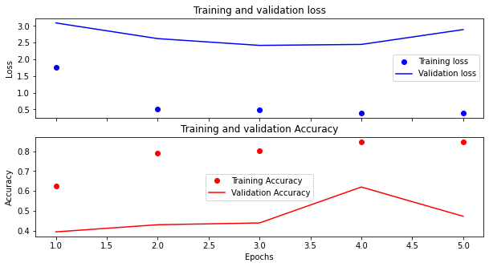

```python
eval_plots(history_optimised_V2)
```

### Utilising Transfer learning

Transfer learning is the process of using pre-trained generalizable models on your specific tasks, this is possible for many deep-learning tasks where there is a similarity in feature space between the two domain problems. Computer vision-related tasks are included in this; many features learned in computer vision are very similar to those that would be seen in completely different tasks, for example; a large, complex neural network could be trained on cars but it would possibly be able to correctly classify jet-skis from trees without any additional training, why is this possible? Because several features learned from a car dataset will be similar to those seen in jet skis, but not in trees. For example; the vibrant colours of jet skis, the sharp angles, and the dark rounded seat may all be identified successfully by this transfer model.

These models are also trained on huge, feature-rich datasets, including this in our model will greatly improve the generalizability of the model.

For these reasons, we make use of several pre-trained models that have achieved state-of-the-art performance on a wide variety of computer vision tasks.

### Transfer learning workflow.

#### Freezing pre-trained model weights

As previously mentioned, the pre-trained model has already been trained on a very large and very rich image dataset, for this reason, the layer weights have already been optimized for general computer vision tasks, and for this reason, we initially freeze the pre-trained model weights. If we didn't do this then the weights would get changed when we initially start fitting our model to our task-specific images.

#### Building a top-layer

Despite these pre-trained models being very powerful it is still important that we define a top layer. That is a few layers that do not have the pre-trained model's weights. This allows us to make task-specific adaptions that the transferred model may not necessarily be great at picking up.

#### Training the top-layer

As mentioned, the pre-trained model's weights are frozen, we can then train our model to optimize the top layer's weights for our task.

#### Fine-tuning the transferred-weights

Once our model has an optimized top layer that is specific to our task, we can train our model again with the transferred weights **unfrozen**, this will change the optimized "general" weights of the model and make them more task-specific. We can do this now, whereas before it may have been a bad idea since our model isn't starting from "scratch", again our top-layer is already optimized for our task.

```python
Xception_augmentation_layer =keras.Sequential(
    [
     layers.RandomFlip("horizontal_and_vertical"),
     layers.RandomBrightness(0.3),

    ] # Xception model requires fixed image size, cant crop
)
```

```python
#define our base model - define here so we dont keep re-creating the same instance in hyper-parameter optimisation.
base_model_Xception = keras.applications.Xception(
    weights="imagenet",  # Load weights pre-trained on ImageNet.
    input_shape=(image_height, image_width, 3),
    include_top=False)

base_model_Xception.trainable = False


base_model_InceptionV3 = keras.applications.inception_v3.InceptionV3(
    weights="imagenet",  # Load weights pre-trained on ImageNet.
    input_shape=(image_height, image_width, 3),
    include_top=False)

base_model_InceptionV3.trainable = False


base_model_EfficentNet = keras.applications.efficientnet.EfficientNetB5(
    weights="imagenet",  # Load weights pre-trained on ImageNet.
    input_shape=(image_height, image_width, 3),
    include_top=False)

base_model_EfficentNet.trainable = False
```

```
Downloading data from https://storage.googleapis.com/tensorflow/keras-applications/xception/xception_weights_tf_dim_ordering_tf_kernels_notop.h5
Downloading data from https://storage.googleapis.com/tensorflow/keras-applications/inception_v3/inception_v3_weights_tf_dim_ordering_tf_kernels_notop.h5
Downloading data from https://storage.googleapis.com/keras-applications/efficientnetb5_notop.h5
```

#### Hyperparameter optimization

This methodology ensures the worst-performing parameters are discarded early on, and only the best parameters are optimized using the full number of epochs.

#### defining a parameter search space

a parameter search space can be defined using a variety of hyperband methods such as:

- hp.Choice: chooses a parameter from a list of parameters
- hp.Boolean: set the value to either 0 or 1
- hp.Float: set the value to a float value between a min and max

A full list of methods can be found here: https://keras.io/api/keras_tuner/hyperparameters/

#### Other useful utilities of hypertune

We can very quickly define a directory to store test results, this ensures if our program crashes, our runtime ends, or we simply re-run the notebook training progress is saved, and it won't re-run any tests that are already completed. we can also make use of **tensorboards** using the keras.callbacks.TensorBoard() callback, we can use this to visualize the tuning and get a better understanding of how different parameter combinations found in our search space perform.

```python
# hyperparameter sets
def model_builder(hp):
  """
    This function builds a Convolutional Neural Network (ConvNet) with the architecture specified and hyperparameters
    selected using Hyperparameter tuning.

    Parameters:
    hp (hyperopt.fmin.Trials): The hyperparameter tuning trials object returned by the Hyperparameter tuning library.

    Returns:
    model (keras.Model): A compiled Keras model with the specified architecture and hyperparameters.

  """
  # define parameter-space
  # NOTE: this parameter-space is in no way exhaustive, we may miss the optimal
  # solution but we are limited on computing power.
  # using quite a higher LR due to limited computing power - i.e limited epochs!

  hp_model_select = hp.Choice("model",values=[""])


 # Do not include the ImageNet classifier at the top.
 # build our task-specific top-layer
  inputs = keras.Input(shape=(image_width,image_height,3))

  x = Xception_augmentation_layer(inputs)
  x= layers.Rescaling(scale=1 / 127.5, offset=-1)(x) # need to scale to [-1,+1] rather than [0,1] for Xception model.

  # give the tuner three base-models to choose from.
  base_model = hp.Choice("base_model", ["Xception", "EfficentNet","InceptionV3"])
  if base_model == "Xception":
    x= base_model_Xception(x,training=False)
  if base_model == "EfficentNet":
    x = base_model_EfficentNet(x,training=False)
  if base_model == "InceptionV3":
    x= base_model_InceptionV3(x,training=False)

  # Add a pooling layer and dropout layer to help with generalizability.
  x = layers.GlobalAveragePooling2D()(x)

  # Give the tuner the option to add between 0, and 2 Dense layers.
  for i in range(hp.Int("num_layers",0,2)):
    x = layers.Dense(hp.Choice('units', values=[256]))(x) # note here we only actually supply one choice.

  #test with and without a dropout layer.
  if hp.Boolean("dropout"):
    x = layers.Dropout(hp.Choice("Dropout",values=[0.5]))(x) #note here we only actually supply one choice.

  x= layers.Flatten()(x)
  outputs= layers.Dense(4,activation="softmax")(x)


  model_Xception=keras.Model(inputs=inputs,outputs=outputs)
  # test with a variety of learning rate
  # in reality we would use hp.Float here to take values between an upper
  # and lower limit, but again we only supply one value here.
  hp_learning_rate = hp.Choice('learning_rate', values=[1e-3])
  model_Xception.compile(keras.optimizers.Adam(learning_rate=hp_learning_rate ),
                  loss="sparse_categorical_crossentropy",
                  metrics=["accuracy"])
  return model_Xception



tuner = kt.Hyperband(model_builder,
                     objective='val_accuracy',
                     max_epochs=15,
                     directory='/content/drive/MyDrive/CW2_models/Xception_model',
                     overwrite=True,
                     executions_per_trial=1, # only run each trial once due to computation limitations
                     project_name='Colon_classifcation'
                    )
```

```python
tuner.search(train_data,
              epochs=10,
              validation_data=validation_data,
              callbacks=[EarlyStopping(patience=3),
                         keras.callbacks.TensorBoard("/content/drive/MyDrive/CW2_models/Xception_model/tmp/tb_logs")])
```

```
Trial 30 Complete [00h 01m 26s]
val_accuracy: 0.7900000214576721

Best val_accuracy So Far: 0.9054999947547913
Total elapsed time: 00h 26m 47s
```

#### Example trial interface:

The below image shows an example of the details shown whilst running a keras trial, at the top we are shown our metrics of choice of both the current trial, and that of the best trial. We also get some run time metrics.

Below we see a table, the right-hand column shows the hyperparameters that are being tuned, these are the parameters defined in the hp methods we define, the central column show the values for each hyperparameter of the best trial so far, and the left column show the values for each hyperparameter in the current trial.

At the bottom you see the interface you would get for calling .fit() on a keras model, that is; the Epoch number, the batches within that epoch, the loss, performance metrics, and any other log values you have definied in your callback functions.

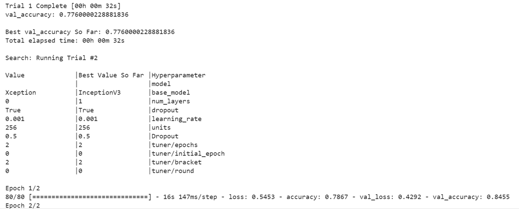

```python
# trial summary, get the performance metrics and parameter values for the 10 best trials.

tuner.results_summary()
```

```
Results summary
Results in /content/drive/MyDrive/CW2_models/Xception_model/Colon_classifcation
Showing 10 best trials
<keras_tuner.engine.objective.Objective object at 0x7f61144cc8b0>
Trial summary
Hyperparameters:
model:
base_model: Xception
num_layers: 1
dropout: True
learning_rate: 0.001
units: 256
Dropout: 0.5
tuner/epochs: 2
tuner/initial_epoch: 0
tuner/bracket: 2
tuner/round: 0
Score: 0.9054999947547913
Trial summary
Hyperparameters:
model:
base_model: Xception
num_layers: 1
dropout: True
learning_rate: 0.001
units: 256
Dropout: 0.5
tuner/epochs: 15
tuner/initial_epoch: 5
tuner/bracket: 2
tuner/round: 2
tuner/trial_id: 0012
Score: 0.9054999947547913
Trial summary
Hyperparameters:
model:
base_model: Xception
num_layers: 0
dropout: False
learning_rate: 0.001
```

[output cut: 95 more lines]

```
Trial summary
Hyperparameters:
model:
base_model: Xception
num_layers: 2
dropout: True
learning_rate: 0.001
units: 256
Dropout: 0.5
tuner/epochs: 5
tuner/initial_epoch: 2
tuner/bracket: 2
tuner/round: 1
tuner/trial_id: 0006
Score: 0.8560000061988831
```

Tensorboards Tensorflow has a cool extension that utilizes the keras.callbacks.TensorBoard() function we passed as a callback in our tuner trials. It shows an in-line interactive dashboard that outlines several interesting features of the trials, for example, accuracy and loss graphs for all trials all in the same place, and hyperparameter graphs that let you see how choosing different parameters lead to different results. One of these graphs is shown below. Note: This is not the full graph! We chose to filter out InceceptionV3 and EfficentNet models for clarity. This is a parallel feature graph, each line represents a model and each vertical line represents a parameter choice or performance metric. We can see some correlation between certain parameter choices and model performance. As an example, For our Xception models the dropout layer was only excluded once (model highlighted in green)and it lead to an incredibly small training_loss value, Clearly this leads to more overfitting than all the other iterations that included the dropout layer! This would also suggest our model requires regularization. If we had access to more GPU power we would test different values for the dropout layer parameter, including more dropout layers, and test different float values for L1 and L2 regularization in our Dense layers

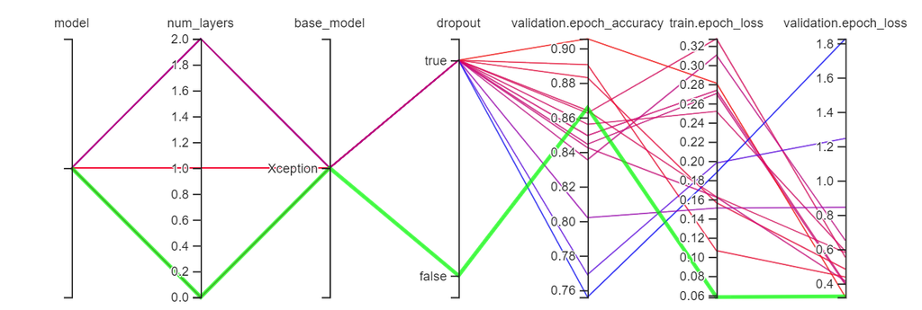

```python
%load_ext tensorboard

%tensorboard --logdir /content/drive/MyDrive/CW2_models/Xception_model/tmp/tb_logs
```

```
The tensorboard extension is already loaded. To reload it, use:
  %reload_ext tensorboard
```

Now we have finished optimisation, leds build a fresh model with the hyperparameters learnt! We choose to only load the parameters so we can train the model from scratch.

```python
# get the hyperparameters from the best trial (the first tria shown in the above summary)
best_params = tuner.get_best_hyperparameters(1)[0]
# build a fresh model with our chosen parameters, we can then train on more epochs, just incase we didnt take it far enough in the trials.
final_model = model_builder(best_params)
# print the final parameter values to be used in our model
best_params.values

# save our model.
#final_model.save("/content/drive/MyDrive/CW2_models/Xception_model/final_model")
```

```
{'model': '',
 'base_model': 'Xception',
 'num_layers': 1,
 'dropout': True,
 'learning_rate': 0.001,
 'units': 256,
 'Dropout': 0.5,
 'tuner/epochs': 2,
 'tuner/initial_epoch': 0,
 'tuner/bracket': 2,
 'tuner/round': 0}
```

```python
# load in our model. We dont really need to do this but since im using colab my
#runtime often ends and Im forced to re-run my notebook.
final_model = keras.models.load_model('/content/drive/MyDrive/CW2_models/Xception_model/final_model')
```

```python
# train our optimised model on 30 epochs with a more lenient earlystop
# we also add a pre-defined callback that monitors val_loss progress and decreases
# the learning rate accordingly.

reduce_lr=tf.keras.callbacks.ReduceLROnPlateau(monitor="val_loss",
                                            factor=0.5,
                                            patience=5,
                                            verbose=1)
final_model_checkpoints = checkpoints("/content/drive/MyDrive/CW2_models/Xception_model/tmp/checkpoint_final_model")
final_model_history=final_model.fit(train_data,
                epochs=30,
                validation_data=validation_data,
                callbacks=[final_model_checkpoints,earlystop(patience=10),
                           EpochTime(),reduce_lr])
```

```
Epoch 9: ReduceLROnPlateau reducing learning rate to 0.0005000000237487257.
Epoch 22: ReduceLROnPlateau reducing learning rate to 0.0002500000118743628.
```

#### Final model review

As we can be seen from the above output the learning rate call back was used twice, after 30 epochs we were able achieve accuracies higher than anything that was achieved in the trials! We will find the best epoch from the above test and then move on to find-tuning the base Xception model.

```python
def get_best_epoch(history):

  lowest_val_loss = min(history.history["val_loss"])

  best_epoch = history.history["val_loss"].index(lowest_val_loss)
  print(f"The best Epoch for this model is: {best_epoch} with a val_loss of: {lowest_val_loss}")
  return best_epoch


final_model_epoch = get_best_epoch(final_model_history)
```

```
The best Epoch for this model is: 25 with a val_loss of: 0.3423885703086853
```

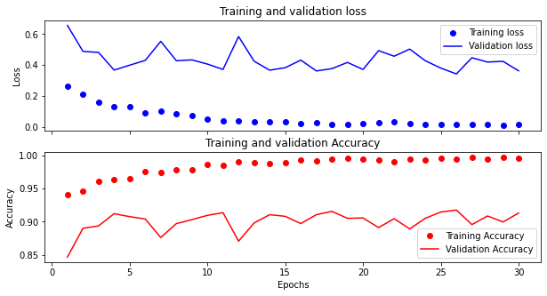

```python
eval_plots(final_model_history)
```

```python
# makesure that the base model we used in our final model is now trainable
final_model_fine_tuned_checkpoints = checkpoints("/content/drive/MyDrive/CW2_models/Xception_model/tmp/checkpoint_final_model_fine_tuned")

base_model_Xception.trainable = True

final_model.compile(
    optimizer=keras.optimizers.Adam(1e-5),  # Low learning rate
    loss="sparse_categorical_crossentropy",
                metrics=["accuracy"],
)
final_model_fine_tuned_history = final_model.fit(train_data, epochs=30, validation_data=validation_data,
          callbacks=[final_model_fine_tuned_checkpoints,earlystop(patience=10),EpochTime(),reduce_lr])
```

```
Epoch 6: ReduceLROnPlateau reducing learning rate to 4.999999873689376e-06.
Epoch 11: ReduceLROnPlateau reducing learning rate to 2.499999936844688e-06.
```

```python
get_best_epoch(final_model_fine_tuned_history)
```

```
The best Epoch for this model is: 0 with a val_loss of: 0.394853800535202
```

```
0
```

Interestingly fine tuning the Xception layer of our model did not lead to any improvement!

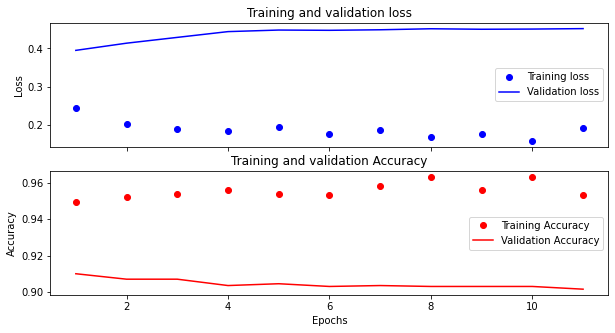

```python
eval_plots(final_model_fine_tuned_history)
```

#### Finishing off the model and making our predictions

Now we have determined what the best model is through hyperband optimisation and chosen the ideal number of epochs to train on, we simply need to re-load the optimal weights from training. Luckily for us this is easy since we made use of the checkpoint callback.

```python
# load our default model, this is just for the architecture, we will
# override the weights.
final_model_optimised = keras.models.load_model('/content/drive/MyDrive/CW2_models/Xception_model/final_model')
```

```python
#override the weights with those found at the optimal epoch
# These will be saved in our checkpoint file.
final_model_optimised.load_weights("/content/drive/MyDrive/CW2_models/Xception_model/tmp/checkpoint_final_model")
```

```
<tensorflow.python.checkpoint.checkpoint.CheckpointLoadStatus at 0x7f7fdecbf520>
```

#### Evaluating our models.

Now we have all of our models we can finally evaluate them on our test data.

We will make use of Sklearn's classifcation_report function which shows class-specific metrics and an overall F1 score. F1-scores encapsulate the distribution of predictions across the classes, so we can get a better understanding of how our models perform across all classes rather than a flat overall accuracy which could do good at predicting certain classes, but be terrible at others.

```python
def evaluate_model(model,test_data):
  y_pred = []
  y_true = np.concatenate([y for x, y in test_data], axis=0)

  preds=model.predict(test_data)

  for i, p in enumerate(preds):
  # for each prediction choose the highest probability one.
        pred_index=np.argmax(p)
        y_pred.append(pred_index)

  print(classification_report(y_true,y_pred))
  return y_pred, y_true
```

```python
# evaluation for our final model
_, __ = evaluate_model(final_model_optimised,test_data)
```

```
              precision    recall  f1-score   support

           0       0.95      0.99      0.97       200
           1       0.90      0.80      0.85       200
           2       0.82      0.90      0.86       200
           3       1.00      0.97      0.99       200

    accuracy                           0.92       800
   macro avg       0.92      0.92      0.92       800
weighted avg       0.92      0.92      0.92       800
```

```python
# evaluation on the model that introduced regularization.

_,__ = evaluate_model(model_optimized_V2,test_data)
```

```
              precision    recall  f1-score   support

           0       0.54      1.00      0.70       200
           1       0.00      0.00      0.00       200
           2       0.38      0.53      0.44       200
           3       1.00      0.73      0.85       200

    accuracy                           0.57       800
   macro avg       0.48      0.57      0.50       800
weighted avg       0.48      0.57      0.50       800
```

```python
# evaluation on the model that introduced data augmentation.

_,__ = evaluate_model(model_optimized_V1,test_data)
```

```
              precision    recall  f1-score   support

           0       0.70      0.91      0.79       200
           1       0.00      0.00      0.00       200
           2       0.50      0.92      0.64       200
           3       0.98      0.84      0.91       200

    accuracy                           0.67       800
   macro avg       0.54      0.67      0.59       800
weighted avg       0.54      0.67      0.59       800
```

```python
# model evaluation for our initial baseline model

_,__ = evaluate_model(base_line_model,test_data)
```

```
              precision    recall  f1-score   support

           0       1.00      1.00      1.00       200
           1       0.00      0.00      0.00       200
           2       0.49      0.98      0.66       200
           3       0.98      0.99      0.99       200

    accuracy                           0.74       800
   macro avg       0.62      0.74      0.66       800
weighted avg       0.62      0.74      0.66       800
```

### Conclusion

#### Lessons learned

If we had known about the issue of 0 precision and 0 recall in class 1 earlier, we would have changed our approach and focused on improving these metrics for class 1. The features that separated this class from the others are seemingly harder, or more complex to learn. Rather than simplifying and regularizing, we should have increased the complexity of our model by adding more capacity in the hopes that these more abstract ideas could be captured.

#### Visualising our final model

Let's delve a little deeper into our final model and try to understand how it succeeds in classifying different colons.

To start we visualize the channels in our model, due to the size of the Xception architecture we won't be able to visualize them all, we choose to look at the first 8 channels of a sub-set of layers. We will do this for an un-seen image belonging to each of the 4 classes so we can get a clear understanding of the difference between classes.

To do this we need to first identify and extract all convolutional layers from our model, these all exist within the Xception layer. Once we have all of the layers that we can visualize we will create a new model that has these layers as the output.

```python
layer_outputs = []
layer_names = []

# need to get the convnet layers from the model.
for outer_layer in final_model_optimised.layers:
  # only convnet layers are within the xception architecutre, so we
  # find the xception layer and then look at the layers nested in there.
  if "xception" in outer_layer.name:
     # The xception layer defines its own input, so we need to save this off
     # to be used in defining our model.
      Xception_input = outer_layer.input

      for inner_layer in outer_layer.layers:
        #if we have a convnet layer then append it to our layer list.
          if "conv" not in inner_layer.name:
            continue
          layer_outputs.append(inner_layer.output)
          # save off the names for the visualisations.
          layer_names.append(inner_layer.name)

# define our activation model and output the convnet layers.
activation_model = keras.Model(inputs=[final_model_optimised.input,
                                     Xception_input],
                               outputs=layer_outputs)
```

```python
# get a sample of images from each of the 4 classes, we sample un-seen examples
# from the test set.

normal_image = []
ulcerative_colitis_image = []
polyps_image = []
esophagitis_image = []

for images, labels in test_data.take(20):
  for i in range(0,len(labels)):
    image_matrix = images[i].numpy().astype("uint8")
    if labels[i]==0:
      normal_image.append(image_matrix)
    if labels[i]==1:
      ulcerative_colitis_image.append(image_matrix)
    if labels[i]==2:
      polyps_image.append(image_matrix)
    if labels[i]==3:
      esophagitis_image.append(image_matrix)
```

```python
# reshape our images into batches of size 1 which is required to run the
# model
normal = normal_image[0].reshape((1,128,128,3))
ulcerative_colitis = ulcerative_colitis_image[0].reshape(1,128,128,3)
polyps = polyps_image[0].reshape(1,128,128,3)
esophagitis = esophagitis_image[0].reshape(1,128,128,3)

# run each of our test images through the activation model to get
# activation layer outputs.
normal_activations = activation_model.predict([normal,normal])
ulcerative_colitis_activations = activation_model.predict([ulcerative_colitis,ulcerative_colitis])
polyps_activations = activation_model.predict([polyps,polyps])
esophagitis_activations = activation_model.predict([esophagitis,esophagitis])
```

```python
# select a sub-set of activation layers to visualise.
layers_to_extract = [1,10,20,30,40,50,60,70,80,90,100,110]


def sample_layers(layers_to_extract,activations):
  '''A function to extract a sub-set of activations and layer names.

  '''


  sample_layer_names = [layer_names[i] for i in layers_to_extract]
  sample_activations = [activations[i] for i in layers_to_extract]
  return sample_layer_names , sample_activations


normal_layer_names,normal_activations = sample_layers(layers_to_extract,normal_activations)
ulcerative_colitis_layer_names,ucerlative_colitis_activations = sample_layers(layers_to_extract,ulcerative_colitis_activations)
polyps_layer_names,polyps_activations = sample_layers(layers_to_extract,polyps_activations)
esophagitis_layer_names,esophagitis_activations = sample_layers(layers_to_extract,esophagitis_activations)
```

```python
def get_activation_grids(layer_names,activations):
    # The base of this function is from Deep learning with Python Edition 2, page 265
  '''
    Returns a list of matrices where each matrix represents the output of an activation layer.

    Arguments:
    layer_names -- a list of strings representing the names of the activation layers.
    activations -- a list of tensors representing the outputs of the activation layers.

    Returns:
    display_grids_all -- a list of matrices, each matrix represents the output of an activation layer.
    layer_name -- a string representing the name of the last activation layer processed.
  '''

  display_grids_all = []
  images_per_row = 4
  for layer_name, layer_activation in zip(layer_names, activations):
      n_features = 8
      size = layer_activation.shape[1]
      n_cols = n_features // images_per_row
      display_grid = np.zeros((size * n_cols, images_per_row * size))
      for col in range(n_cols):
          for row in range(images_per_row):
            channel_image = layer_activation[0,
            :, :,
            col * images_per_row + row]
            channel_image -= channel_image.mean()
            channel_image /= channel_image.std()
            channel_image *= 64
            channel_image += 128
            channel_image = np.clip(channel_image, 0, 255).astype('uint8')
            display_grid[col * size : (col + 1) * size,
            row * size : (row + 1) * size] = channel_image

      display_grids_all.append(display_grid)

  return display_grids_all, layer_name
```

```python
# get our activation layer outputs from each image
norm_grids = get_activation_grids(normal_layer_names,normal_activations)
ulcerative_grids = get_activation_grids(normal_layer_names,ulcerative_colitis_activations)
polyps_grids = get_activation_grids(normal_layer_names,polyps_activations)
esophagitis_grids = get_activation_grids(normal_layer_names,esophagitis_activations)
```

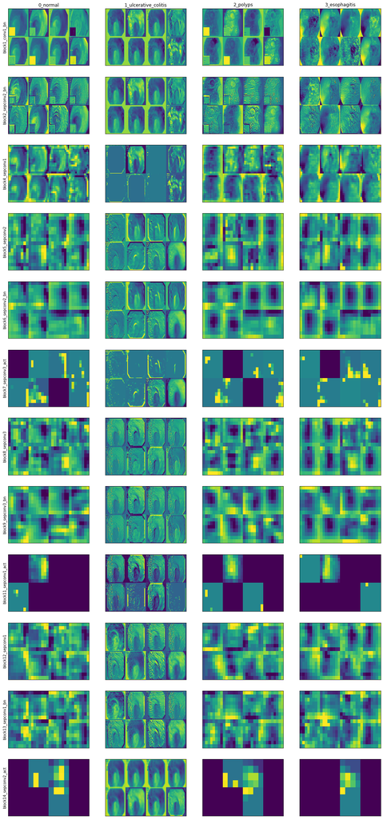

```python
# visualise our activation layers
fig, ax = plt.subplots(12,4,figsize=(18,40))
for col,grid in enumerate([norm_grids,ulcerative_grids,polyps_grids,esophagitis_grids]):
  row = 0
  for layer,name in zip(grid,normal_layer_names):
    ax[row,0].set_ylabel(name)
    ax[0,col].set_title(class_names[col])
    ax[row,col].set_xticks([])
    ax[row,col].set_yticks([])

    ax[row,col].imshow(layer, aspect='auto', cmap='viridis')
    row +=1
```